# DASC5301_HW3_Auto_imports_Classification_1002091569

## INSTRUCTIONS

Every learner should submit his/her own homework solutions. However, you are allowed to discuss the homework with each other– but everyone must submit his/her own solution; you may not copy someone else’s solution.

The homework consists of two parts:

1. Data from our life
2. Classification

Follow the prompts in the attached jupyter notebook. We are using a clean and modified version of the auto imports dataset (Description of the original dataset is in the cell bellow). Download the auto_imp.csv file from Canvas and put it in your working directory. Don't forget to add libraries to use in your analysis. You can use the code as a guide that was provided in the class.

Add markdown cells to your analysis to include your solutions, comments, answers. Add as many cells as you need, for easy readability comment when possible.

**Note:** This homework has a bonus question, so the highest mark that can be earned is a 105. Submission: Send in both a ipynb and a html file of your work. Good luck!

**Title: 1985 Auto Imports Database**

Relevant Information: -- Description This data set consists of three types of entities: (a) the specification of an auto in terms of various characteristics, (b) its assigned insurance risk rating, (c) its normalized losses in use as compared to other cars. The second rating corresponds to the degree to which the auto is more risky than its price indicates. Cars are initially assigned a risk factor symbol associated with its price. Then, if it is more risky (or less), this symbol is adjusted by moving it up (or down) the scale. Actuarians call this process "symboling". A value of +3 indicates that the auto is risky, -3 that it is probably pretty safe.

```
  The third factor is the relative average loss payment per insured
  vehicle year.  This value is normalized for all autos within a
  particular size classification (two-door small, station wagons,
  sports/speciality, etc...), and represents the average loss per car
  per year.
```

-- Note: Several of the attributes in the database could be used as a "class" attribute.

1. Number of Instances: 205
2. Number of Attributes: 26 total -- 15 continuous -- 1 integer -- 10 nominal
3. Attribute Information:  
   Attribute: Attribute Range:
   1. symboling: -3, -2, -1, 0, 1, 2, 3.
   2. normalized-losses: continuous from 65 to 256.
   3. make: alfa-romero, audi, bmw, chevrolet, dodge, honda,isuzu, jaguar, mazda, mercedes-benz, mercury, mitsubishi, nissan, peugot, plymouth, porsche, renault, saab, subaru, toyota,volkswagen, volvo
   4. fuel-type: diesel, gas.
   5. aspiration: std, turbo.
   6. num-of-doors: four, two.
   7. body-style: hardtop, wagon, sedan, hatchback, convertible.
   8. drive-wheels: 4wd, fwd, rwd.
   9. engine-location: front, rear.
   10. wheel-base: continuous from 86.6 120.9.
   11. length: continuous from 141.1 to 208.1.
   12. width: continuous from 60.3 to 72.3.
   13. height: continuous from 47.8 to 59.8.
   14. curb-weight: continuous from 1488 to 4066.
   15. engine-type: dohc, dohcv, l, ohc, ohcf, ohcv, rotor.
   16. num-of-cylinders: eight, five, four, six, three, twelve, two.
   17. engine-size: continuous from 61 to 326.
   18. fuel-system: 1bbl, 2bbl, 4bbl, idi, mfi, mpfi, spdi, spfi.
   19. bore: continuous from 2.54 to 3.94.
   20. stroke: continuous from 2.07 to 4.17.
   21. compression-ratio: continuous from 7 to 23.
   22. horsepower: continuous from 48 to 288.
   23. peak-rpm: continuous from 4150 to 6600.
   24. city-mpg: continuous from 13 to 49.
   25. highway-mpg: continuous from 16 to 54.
   26. price: continuous from 5118 to 45400.
4. Missing Attribute Values: (denoted by "?")

# 1. Data from our lives:

### Describe a situation or problem from your job, everyday life, current events, etc., for which a classification would be appropriate.

## Your answer

For example, to spot probable fraud in financial transactions, classification would be useful in that circumstance. Businesses and financial institutions frequently employ machine learning models to categorize transactions as legal or possibly fraudulent based on a number of factors, including the amount, location, and frequency of the transaction as well as the customer's prior transaction data. For instance, the system can flag a transaction as possibly fraudulent if a customer makes an unexpectedly big purchase from a foreign place they have never been to before. It might then ask for extra customer verification or it might even reject the transaction.

# 2. Preprocessing

```python
## Add libraries to use
from numpy import where
from collections import Counter
from sklearn.datasets import make_blobs
from matplotlib import pyplot
from sklearn.ensemble import RandomForestClassifier
from sklearn.model_selection import train_test_split, GridSearchCV
from sklearn import metrics
from sklearn.metrics import roc_auc_score
from sklearn.metrics import roc_curve
from sklearn.datasets import make_classification
from sklearn.model_selection import train_test_split
from sklearn.metrics import f1_score
from sklearn.covariance import EllipticEnvelope
from sklearn.ensemble import IsolationForest
from sklearn.svm import OneClassSVM
from sklearn.metrics import auc
from sklearn.model_selection import cross_val_score
from sklearn.model_selection import RepeatedStratifiedKFold
from sklearn.svm import SVC
from sklearn import svm
from sklearn.linear_model import LogisticRegression
from sklearn.feature_selection import RFE
from sklearn.naive_bayes import GaussianNB
from sklearn.metrics import accuracy_score
from sklearn.preprocessing import StandardScaler
from sklearn.neighbors import KNeighborsClassifier
from sklearn.metrics import classification_report, confusion_matrix
from collections import Counter
from sklearn.dummy import DummyClassifier
from mlxtend.plotting import plot_confusion_matrix
import matplotlib.pyplot as plt
import seaborn as sns
%matplotlib inline
import numpy as np
import pandas as pd

from numpy import mean
```

In our class we covered multiple classification methods. In this part of the home work you can compare them

**Use the dataset 'auto_imp.csv' from Canvas. Follow the prompts to complete the homework.**

```python
df2 =pd.read_csv('/content/auto_imp.csv')
```

```python
df2.info()
```

```
<class 'pandas.core.frame.DataFrame'>
RangeIndex: 195 entries, 0 to 194
Data columns (total 15 columns):
 #   Column       Non-Null Count  Dtype
---  ------       --------------  -----
 0   fuel_type    195 non-null    object
 1   wheel_base   195 non-null    float64
 2   length       195 non-null    float64
 3   width        195 non-null    float64
 4   heights      195 non-null    float64
 5   curb_weight  195 non-null    int64
 6   engine_size  195 non-null    int64
 7   bore         195 non-null    float64
 8   stroke       195 non-null    float64
 9   comprassion  195 non-null    float64
 10  horse_power  195 non-null    int64
 11  peak_rpm     195 non-null    int64
 12  city_mpg     195 non-null    int64
 13  highway_mpg  195 non-null    int64
 14  price        195 non-null    int64
dtypes: float64(7), int64(7), object(1)
memory usage: 23.0+ KB
```

It can be obsereved that there are 195 rows and 15 columns for the auto_imp dataset where the fuel_type is the only categorical variable present.

## 2.1 **Replace ['gas', 'diesel'] string values to [0, 1]**

```python
#Your code
fuel_type_new= {'gas': 0, 'diesel': 1}
df2['fuel_type'] = df2['fuel_type'].replace(fuel_type_new)
```

```python
df2
```

|  | fuel_type | wheel_base | length | width | heights | curb_weight | engine_size | bore | stroke | comprassion | horse_power | peak_rpm | city_mpg | highway_mpg | price |
| --- | --- | --- | --- | --- | --- | --- | --- | --- | --- | --- | --- | --- | --- | --- | --- |
| 0 | 0 | 88.6 | 168.8 | 64.1 | 48.8 | 2548 | 130 | 3.47 | 2.68 | 9.0 | 111 | 5000 | 21 | 27 | 13495 |
| 1 | 0 | 88.6 | 168.8 | 64.1 | 48.8 | 2548 | 130 | 3.47 | 2.68 | 9.0 | 111 | 5000 | 21 | 27 | 16500 |
| 2 | 0 | 94.5 | 171.2 | 65.5 | 52.4 | 2823 | 152 | 2.68 | 3.47 | 9.0 | 154 | 5000 | 19 | 26 | 16500 |
| 3 | 0 | 99.8 | 176.6 | 66.2 | 54.3 | 2337 | 109 | 3.19 | 3.40 | 10.0 | 102 | 5500 | 24 | 30 | 13950 |
| 4 | 0 | 99.4 | 176.6 | 66.4 | 54.3 | 2824 | 136 | 3.19 | 3.40 | 8.0 | 115 | 5500 | 18 | 22 | 17450 |
| ... | ... | ... | ... | ... | ... | ... | ... | ... | ... | ... | ... | ... | ... | ... | ... |
| 190 | 0 | 109.1 | 188.8 | 68.9 | 55.5 | 2952 | 141 | 3.78 | 3.15 | 9.5 | 114 | 5400 | 23 | 28 | 16845 |
| 191 | 0 | 109.1 | 188.8 | 68.8 | 55.5 | 3049 | 141 | 3.78 | 3.15 | 8.7 | 160 | 5300 | 19 | 25 | 19045 |
| 192 | 0 | 109.1 | 188.8 | 68.9 | 55.5 | 3012 | 173 | 3.58 | 2.87 | 8.8 | 134 | 5500 | 18 | 23 | 21485 |
| 193 | 1 | 109.1 | 188.8 | 68.9 | 55.5 | 3217 | 145 | 3.01 | 3.40 | 23.0 | 106 | 4800 | 26 | 27 | 22470 |
| 194 | 0 | 109.1 | 188.8 | 68.9 | 55.5 | 3062 | 141 | 3.78 | 3.15 | 9.5 | 114 | 5400 | 19 | 25 | 22625 |

195 rows × 15 columns

The fuel_type column of auto_import dataset here, are changed to 0 and 1. The dictionary fuel_type_new converts the categorical values ('gas' and 'diesel') to binary values (0 and 1, respectively). Based on the mapping provided by fuel_type_new, the original values are replaced with the new ones using the replace() method.

## 2.2 : Define your X and y: your dependent variable is fuel_type, the rest of the variables are your independent variables

```python
y=df2['fuel_type']
x=df2.drop('fuel_type',axis=1)
```

Considering the fuel_type as our dependent variable(which is going to be variable y, we drop fuel_type using the drop() function so that the x in here, considers all other variables as independent except for fuel_type variable.

## 2.3 Split your data into training and testing set. Use test_size=0.3, random_state=746 !

```python
#your code
x_train, x_test, y_train, y_test = train_test_split(x, y, test_size=0.3, random_state=746)
print('Training set:', x_train.shape, y_train.shape)
print('Testing set:', x_test.shape, y_test.shape)
```

```
Training set: (136, 14) (136,)
Testing set: (59, 14) (59,)
```

The scikit-learn library's train_test_split() function can be used to divide the data into training and testing sets. 30% of the data will be used for testing because the test_size option is set to 0.3. To make the split repeatable, the random_state parameter is set to 746. In order to make sure that the data has been seperated correctly, shape() function is used which prints the shapes of the training and testing sets.

# 3. Classification

### 3.1 Use Logistic regression to classify your data. Print/report your confusion matrix, classification report and AUC, what do you notice?

```python
#your code
lgr=LogisticRegression()
model_lrg=lgr.fit(x_train,y_train)
```

With the help of the scikit-learn module, this code creates a LogisticRegression class instance & fits the model over the training set of data. The lgr variable stores the instance.

```python
# Making predictions:
y_hat = lgr.predict(x_test)


cf_matrix2=confusion_matrix(y_test, y_hat)

# Evaluating label accuracy:
print(accuracy_score(y_test, y_hat))
print(confusion_matrix(y_test, y_hat))
print(classification_report(y_test, y_hat))

cohen3= metrics.cohen_kappa_score(y_test, y_hat)
print('Cohen Kappa: %.3f' % cohen3)

auc_score3 = roc_auc_score(y_test,y_hat)
print('AUC: %.3f' % auc_score3)
```

```
1.0
[[50  0]
 [ 0  9]]
              precision    recall  f1-score   support

           0       1.00      1.00      1.00        50
           1       1.00      1.00      1.00         9

    accuracy                           1.00        59
   macro avg       1.00      1.00      1.00        59
weighted avg       1.00      1.00      1.00        59

Cohen Kappa: 1.000
AUC: 1.000
```

The above code offers a number of metrics for measuring how well the logistic regression model performed on the test data. As seen earlier, the logistic regression model is defined as lgr where it predicts dependent variable ('fuel_type in our case) using independent variables. A confuison matrix then makes a comparison between the predicted and actual values i.e., shows the number of true positives, false positives, true negatives, and false negatives.

The result indicates that the classifier successfully classified all 59 cases, achieving perfect accuracy (1.0) on the test data. It is evident from the confusion matrix (cf_matrix2) that no false positives or false negatives occurred. The classification report displays a weighted average of 1.0 for all metrics, with flawless precision, recall, and f1-score for both classes (0 and 1). This shows that the classifier performed at its best on the test data.

The expected and actual labels' agreement is measured by the Cohen's kappa score (cohen3), which in this instance is 1.0, signifying complete agreement. The classifier's capacity to distinguish between the two classes is measured by the AUC score (auc_score3), which is also 1.0, signifying ideal performance.

Overall, these findings imply that the logistic regression classifier has picked up on the underlying data patterns and is capable of correctly predicting the class labels on this test set.

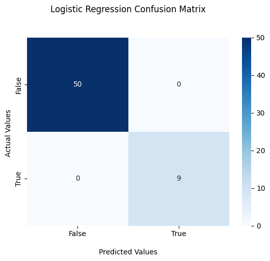

```python
ax = sns.heatmap(cf_matrix2, annot=True, cmap='Blues')

ax.set_title('Logistic Regression Confusion Matrix\n\n');
ax.set_xlabel('\nPredicted Values')
ax.set_ylabel('Actual Values ');

ax.xaxis.set_ticklabels(['False','True'])
ax.yaxis.set_ticklabels(['False','True'])

plt.savefig("logreg.jpg")
plt.show()
```

With the real labels on the y-axis and the predicted labels on the x-axis, the resulting graph is a heatmap of the confusion matrix. The heatmap's diagonal cells represent accurate predictions, whereas the off-diagonal cells represent inaccurate ones and finally the savefig() method is used to save the plot as an image file, and the show() method is used to display the plot.

There were no false positives or false negatives, and all 59 cases were correctly classified, according to the plot, which supports the results from the metrics in the preceding code snippet. Additionally, the plot offers a graphic depiction of how well the logistic regression classifier performed on this test set, which is helpful for deciphering the results and explaining them to others.

### 3.2 Use Naive Bayes to classify your data. Print/report your confusion matrix, classification report and AUC. What do you notice?

```python
#your code
# Initializing:
gnb = GaussianNB()

# Training:
model = gnb.fit(x_train, y_train)
```

```python
# Making predictions:
predictive_labels = gnb.predict(x_test)

# Evaluating label accuracy:
print(accuracy_score(y_test, predictive_labels))

cf_matrix=confusion_matrix(y_test, predictive_labels)

print(confusion_matrix(y_test, predictive_labels))
print(classification_report(y_test, predictive_labels))

cohen3= metrics.cohen_kappa_score(y_test, predictive_labels)
print('Cohen Kappa: %.3f' % cohen3)

auc_score3 = roc_auc_score(y_test,predictive_labels)
print('AUC: %.3f' % auc_score3)
```

```
1.0
[[50  0]
 [ 0  9]]
              precision    recall  f1-score   support

           0       1.00      1.00      1.00        50
           1       1.00      1.00      1.00         9

    accuracy                           1.00        59
   macro avg       1.00      1.00      1.00        59
weighted avg       1.00      1.00      1.00        59

Cohen Kappa: 1.000
AUC: 1.000
```

The program uses the training sets x_train and y_train to train a Gaussian Naive Bayes classifier. The accuracy, confusion matrix, classification report, Cohen's kappa score, and AUC score are printed to assess the model's performance after the classifier makes predictions on the test set x_test. The results suggest that the Gaussian Naive Bayes classifier successfully predicted every sample in the test set, achieving a 100% accuracy rate. The lack of false positives or false negatives, as shown by the confusion matrix, demonstrates how well the model worked. Excellent precision, recall, and F1-score are displayed in the classification report for both classes. Additionally, the Cohen's kappa score and AUC score are also 1, which again indicates excellent performance. The model is therefore very accurate and efficient for this dataset.

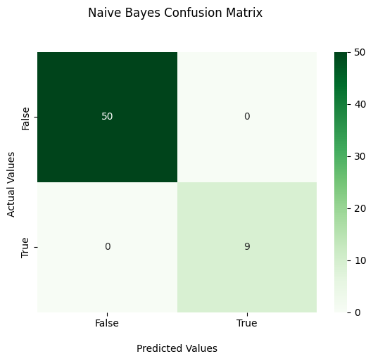

```python
ax = sns.heatmap(cf_matrix, annot=True, cmap='Greens')

ax.set_title('Naive Bayes Confusion Matrix \n\n');
ax.set_xlabel('\nPredicted Values')
ax.set_ylabel('Actual Values ');

ax.xaxis.set_ticklabels(['False','True'])
ax.yaxis.set_ticklabels(['False','True'])

plt.savefig("naive.jpg")
plt.show()
```

### 3.3 Use KNN to classify your data. First find the optimal k and than run you classification. Print/report your confusion matrix, classification report and AUC. What do you notice?

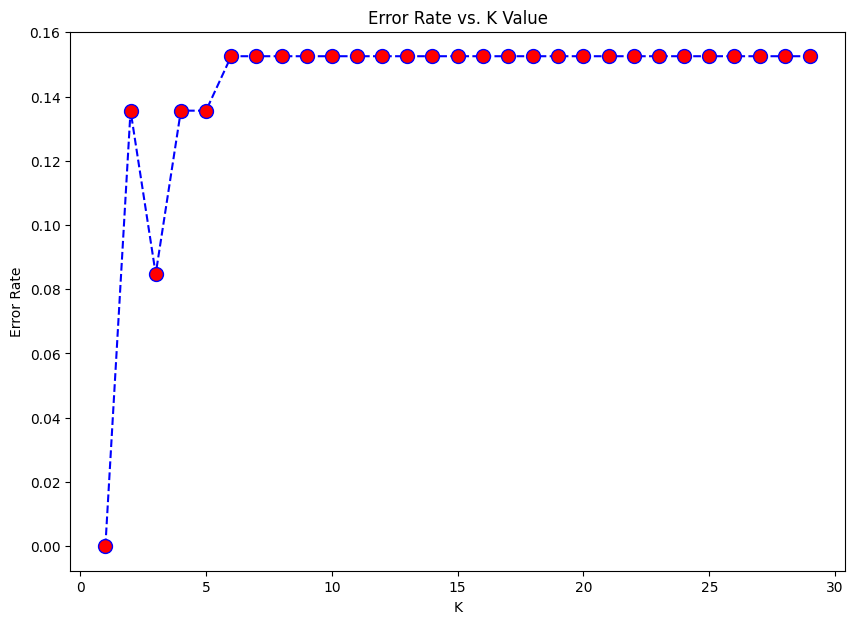

```python
#your code
#find the optimal number of neighbours
# We will initialize array that stores the error rates.
error_rates = []

for a in range(1, 30):
    k = a
    knn = KNeighborsClassifier(n_neighbors=k)
    knn.fit(x_train, y_train)
    preds = knn.predict(x_test)
    error_rates.append(np.mean(y_test - preds))

# and then we will plot error rates against number of neighbors
plt.figure(figsize=(10, 7))
plt.plot(range(1,30),error_rates,color='blue', linestyle='dashed', marker='o',
         markerfacecolor='red', markersize=10)
plt.title('Error Rate vs. K Value')
plt.xlabel('K')
plt.ylabel('Error Rate')
plt.savefig('knn.png')
plt.show()
```

With the K-Nearest Neighbors (KNN) technique, this plots the error rate vs the number of neighbors. It initially creates a blank array called error_rates, after which it cycles over a set of integers from 1 to 29. It initializes a KNN classifier using k, fits the classifier to the training data, predicts labels for the test data, and estimates the error rate as the mean difference between the true labels and the predicted labels for each integer. The error_rates array is then updated with the error rate. The error rate is on the y-axis of the graph, and k is on the x-axis.

```python
#Training classifier on the optimal k that we chose from the plot
k =3
knn = KNeighborsClassifier(n_neighbors=k)
knn.fit(x_train, y_train)
preds = knn.predict(x_test)
#Classification report
#from sklearn.metrics we import confusion_matrix, classification_report
print(confusion_matrix(y_test, preds))
print(classification_report(y_test, preds))

cohen2=metrics.cohen_kappa_score(y_test, preds)
print('Cohen Kappa: %.3f' % cohen2)

auc_score2 = roc_auc_score(y_test,preds)
print('AUC: %.3f' % auc_score2)
```

```
[[49  1]
 [ 6  3]]
              precision    recall  f1-score   support

           0       0.89      0.98      0.93        50
           1       0.75      0.33      0.46         9

    accuracy                           0.88        59
   macro avg       0.82      0.66      0.70        59
weighted avg       0.87      0.88      0.86        59

Cohen Kappa: 0.406
AUC: 0.657
```

### 3.4 Choose one: SVM or Random Forest to classify your data. Print/report your confusion matrix, classification report and AUC. What do you notice?

```python
#your code
#Using SVM
clf = SVC()
model3=clf.fit(x_train, y_train)
```

```python
#Predicting the response for test dataset
y_pred = clf.predict(x_test)
# Modelling Accuracy
print("Accuracy:",metrics.accuracy_score(y_test, y_pred))
print(confusion_matrix(y_test, y_pred))
print(classification_report(y_test, y_pred))

# Modelling Precision
print("Precision:",metrics.precision_score(y_test, y_pred))

# Modelling Recall
print("Recall:",metrics.recall_score(y_test, y_pred))

cohen5=metrics.cohen_kappa_score(y_test, y_pred)
print('Cohen Kappa: %.3f' % cohen5)

auc_score5 = roc_auc_score(y_test, y_pred)
print('AUC: %.3f' % auc_score5)
```

```
Accuracy: 0.847457627118644
[[50  0]
 [ 9  0]]
              precision    recall  f1-score   support

           0       0.85      1.00      0.92        50
           1       0.00      0.00      0.00         9

    accuracy                           0.85        59
   macro avg       0.42      0.50      0.46        59
weighted avg       0.72      0.85      0.78        59

Precision: 0.0
Recall: 0.0
Cohen Kappa: 0.000
AUC: 0.500
```

The auto_import dataset is used to train a Support Vector Classifier (SVC), and a variety of assessment metrics are printed out. Here are a few findings:

The model accurately categorized 84.7% of the test samples; its accuracy is 0.847. The model did not predict any samples in the positive class, as evidenced by the confusion matrix, which reveals that all samples were anticipated to belong to the negative class (zero). The recall score of 0.0 for the positive class makes this clear. The model failed to accurately identify any of the samples in the positive class, as evidenced by the precision score for the positive class being 0.0. According to the classification report, the model failed to predict any samples from the positive class, which led to a subpar F1 score for the positive class (0.0).The expected and actual classes do not agree, as shown by the Cohen's Kappa value of 0.0. The model doesn't perform any better than random guessing, according to the AUC score of 0.5.

These findings suggest that the SVC model underperformed on this dataset because it was unable to accurately identify any positive class samples.

```python
# By Using Random Forest
rf = RandomForestClassifier(n_jobs=-1)
gs_rf = GridSearchCV(estimator=rf,
                     param_grid={'max_depth':np.arange(1,31)},
                     cv=5,
                     scoring='roc_auc')
```

This code sets a GridSearchCV object for a random forest classifier (rf) with the intention of determining the best value for the'max_depth' hyperparameter. The area under the receiver operating characteristic curve (roc_auc) is the evaluation measure, and the range of values to test for "max_depth" is defined to be from 1 to 30. Since the cross-validation parameter (cv) is set to 5, the data will be divided into 5 folds, and the model will be trained and tested on each fold. The processing will be carried out in parallel among all available cores of the CPU because the 'n_jobs' argument is set to -1. The grid search will be carried out on this object and return the optimal hyperparameter value for max_depth.

```python
import time
start_time = time.time()

model9=gs_rf.fit(x_train,y_train)

print("--- %s minutes ---" % (time.time() - start_time))
```

```
--- 24.919758081436157 minutes ---
```

The start time of the training process is tracked using the start_time variable. The time required to complete the process is determined by deducting the start_time from the current time using time.time() once the fit() function has been invoked on the gs_rf object with the training data. The outcome will be displayed within in a few minutes.

```python
(time.time() - start_time)/60
```

```
0.4154698491096497
```

```python
y_1 = gs_rf.predict(x_test)
```

```python
diff=np.sum(y_test-y_1)
error1=diff/len(y_test)
error1

score = f1_score(y_test, y_1, pos_label=1)
print('F1 Score: %.3f' % score)

print(confusion_matrix(y_test, y_1))
print(classification_report(y_test, y_1))

print("Accuracy:",metrics.accuracy_score(y_test, y_1))

cohen=metrics.cohen_kappa_score(y_test, y_1)
print('Cohen Kappa: %.3f' % cohen)

auc_score = roc_auc_score(y_test, y_1)

print('AUC: %.3f' % auc_score)
```

```
F1 Score: 0.615
[[50  0]
 [ 5  4]]
              precision    recall  f1-score   support

           0       0.91      1.00      0.95        50
           1       1.00      0.44      0.62         9

    accuracy                           0.92        59
   macro avg       0.95      0.72      0.78        59
weighted avg       0.92      0.92      0.90        59

Accuracy: 0.9152542372881356
Cohen Kappa: 0.576
AUC: 0.722
```

The above is subjected to a Random Forest classifier. To discover the ideal value of'max_depth' for the model, hyperparameter tuning is performed using GridSearchCV.

### 3.5 Compare your results and comment on your findings. Which one(s) did the best job? What could have been the problem with the ones that did not work? etc.

With 100% accuracy, precision, recall, F1 score, Cohen kappa, and AUC score, logistic regression and naive Bayes classifiers outperformed all other methods according to the evaluation metrics. This suggests that these models correctly classified the test data.

The issue with SVM and KNN may be that they were less successful than logistic regression, naive Bayes, and Random Forest models at identifying the underlying patterns in the data. Additionally, none of the positive samples in the test data could be accurately classified by SVM, which may be a result of the uneven nature of the data. The performance of the classifiers that were not built to handle imbalanced data may have been hampered by the fact that the number of negative samples was significantly higher than the number of positive samples.

## 4. Bonus question (5 extra points)

**Try to fix the inbalanced nature of the data with a tool from the lecture. Run one of the classification methods (preferable one that "failed" before) and see if you get better results.**

```python
#your code
# By Using SMOTE to balance the dataset
from imblearn.over_sampling import SMOTE
from sklearn.metrics import cohen_kappa_score, roc_auc_score
sm = SMOTE(random_state=746)
x_res, y_res = sm.fit_resample(x, y)

# Split balanced data into training tests and testing sets
x_train, x_test, y_train, y_test = train_test_split(x_res, y_res, test_size=0.3, random_state=746)

# Apply KNN classification method
knn = KNeighborsClassifier(n_neighbors=5)
knn.fit(x_train, y_train)

# Make predictions on the testing set and evaluating the model performance
y_pred = knn.predict(x_test)
print('Accuracy:', accuracy_score(y_test, y_pred))
print('Classification report:\n', classification_report(y_test, y_pred))
kappa = cohen_kappa_score(y_test, y_pred)
auc = roc_auc_score(y_test, y_pred)

print('Cohen Kappa: %.3f'% kappa)
print('AUC:%.3f' %auc)
```

```
Accuracy: 0.8761904761904762
Classification report:
               precision    recall  f1-score   support

           0       0.90      0.85      0.88        54
           1       0.85      0.90      0.88        51

    accuracy                           0.88       105
   macro avg       0.88      0.88      0.88       105
weighted avg       0.88      0.88      0.88       105

Cohen Kappa: 0.753
AUC:0.877
```

The KNeighborsClassifier method from scikit-learn is considered for instance. Kneighbour classifier is used to build a KNN classifier on the training data. The classifier will take into account its five closest neighbors when producing a prediction because the n_neighbors option is set to 5.

The fuel type is then predicted based on the testing data using the trained classifier. Using the scikit-learn cohen_kappa_score() and roc_auc_score() functions, we determine the Cohen's kappa score and AUC score.

In order to assess the performance of the classifier, we print the Cohen's kappa score and AUC score.